# Interview mit Kornél Mundruczó - Bayerische Staatsoper

[figure not shown]

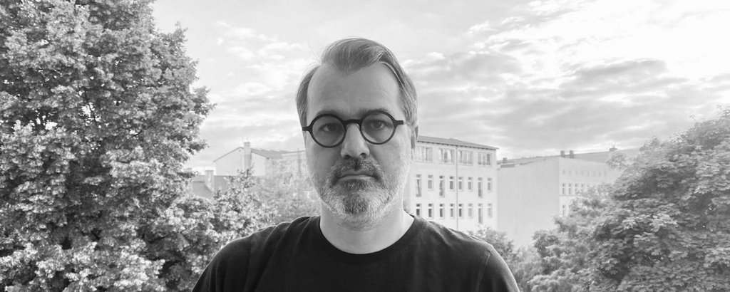

# Die Imagination eines Helden

Ein Gespräch vor Probenbeginn mit dem Regisseur Kornél Mundruczó

VON MALTE KRASTING

**Wie war Ihr Verhältnis zu Richard Wagner in der Vergangenheit?**

Kornél Mundrczó: Mit Wagner und seinem Schaffen verbinden mich persönlich zwei Aspekte. Zum einen ist Wagner in Ungarn, meinem Heimatland, so etwas wie ein Brennglas: In unserem Verhältnis zu Wagner spiegelt sich unsere Sicht auf den großen Nachbarn Deutschland und alles, was wir an Deutschland schätzen und was wir kritisieren. All die gegensätzlichen Bewertungen, die seine Person und sein Werk erfahren, dienen als Stellvertreterargumente. Darüber hinaus war sein Einfluss auf die ungarische Literatur substantiell, seine Stoffe und sein dramatischer Zugriff wirken bis heute nach. Ich selbst habe in dieser Hinsicht die Nibelungen-Sage auf die Bühne gebracht, in einer Überschreibung der germanischen Quellen durch den viel zu früh verstorbenen ungarischen Schriftsteller János Térey (*Nibelungen-Wohnpark,* 2004, mit dem Ensemble Krétakör).

Eine andere Verbindung geht zurück in meine Kindheit, in der ich oft Ouvertüren und orchestrale Passagen aus Wagners Opern gehört habe, und ich erinnere mich, wie mich schon damals die unendliche Schönheit seiner Musik berührt hat. Das waren ganz naive Eindrücke, manchmal ohne überhaupt zu wissen, dass es sich um Wagner handelte. Aber als ich mich später mit ihm auseinanderzusetzen begann und seine Werke neu entdeckte, wurden diese Erinnerungen wieder geweckt, an das Erleben einer entwaffnenden Schönheit – für mich als Kind wie als Erwachsenen gleichermaßen. Diese Empfindung ist, bei allem Bewusstsein für seine problematische Stellung in der Geschichte, nicht nur der Musikgeschichte, unverändert geblieben.

Der innere Widerspruch macht Wagner für mich zu einer zerbrechlichen Erscheinung. Zerbrechlich, weil er so gegensätzliche Eigenschaften in sich vereint – fast wie ein bipolarer Charakter. Das findet sich eigentlich in jedem Aspekt der Handlung und in jeder der Hauptfiguren seiner Musikdramen. So großspurig und vereinnahmend uns Wagner in seinen Briefen und Äußerungen oft entgegentritt, so fragil scheinen mir seine Seele, seine Gedanken, seine ganze Existenz. Und ohne die Tiefe und verletzliche Aufrichtigkeit seiner Musik würden viele Konstellationen in seinen Texten kollabieren.

**Lohengrin ist ein scheinbar fehlerloser Held, unbefleckt und makellos. Jedenfalls an der Oberfläche. Wie gehen Sie mit diesem Phänomen um?**

Diese Oper besteht aus wunderbarer Musik und einer problematischen Handlung. Lohengrin ist dargestellt als wahrer Held ohne Schattenseiten, ohne viele Schattierungen. Darin liegt für mich geradezu der Schlüssel zum Stück. Lohengrin ist keine richtige Persönlichkeit, die von irgendjemandem nach Brabant gesandt wird. Er entsteht durch den Glauben an ihn, er wird durch uns, durch die Menschen, die ihn sich vorstellen, erschaffen. Eine Menschenmenge, die auf Erlösung wartet, imaginiert sich diesen an eine Tyrannengestalt grenzenden Helden – unberührt und unberührbar, völlig pur und übermenschlich –, dem man ohne zu zweifeln zu folgen hat.

Ich persönlich glaube nicht daran, dass Gott (oder ein Gott) uns Königinnen und Könige oder Pharaos und Politiker schickt. Ich bin überzeugt, dass all diese Erscheinungen die Geschöpfe der Gesellschaft um sie herum sind. Was ich an der Oper *Lohengrin* so bewundere, ist, dass sie in die Tiefe dieser Krise führt: eine gesellschaftliche, globale Krise, in der der Menschheit die Menschlichkeit aus dem Blick geraten ist und in der deshalb solche Erscheinungen Gestalt annehmen können. Es hat für mich etwas von einer Post-Humanität, in der die Menschen die Erkenntnisse der Aufklärung wieder verdrängt haben und wo an die Stelle von Eigenverantwortung die Hoffnung auf eine Person getreten ist, die von irgendwoher auftaucht, um alle Probleme zu lösen und die Antwort auf alle Fragen mitbringt.

Ich komme aus Osteuropa, aus einem seit vielen Jahren krisengeschüttelten Land, wo einem hoffnungsvollen Aufschwung ein Absturz folgte und seitdem alle Leute auf Rettung warten. In solch einer Situation kann man als charismatische Persönlichkeit in wenigen Monaten eine große Karriere machen. Das ist das Wesen des Populismus zu allen Zeiten. Provokant formuliert: Man kann die Oper *Lohengrin* so lesen, als wäre ihr Titelheld eine populistische Figur. Er ist so rein, wie man sich nur auf Instagram inszenieren kann. Ein menschengemachtes Idol.

**Boris Voigt betont in seinem Beitrag in diesem Programmheft, dass *Lohengrin* von zwei Charismatikern geprägt ist: vom Titelhelden und von Ortrud.**

Die Dualität zwischen Lohengrin und Ortrud ist für mich eine weitere wesentliche Säule des Dramas. Ich verstehe Ortrud als eine rational denkende Frau und kann ihren Standpunkt durchaus nachvollziehen. Sie ist keine eindimensionale Hexe. Sie verwendet zwar fragwürdige Mittel in ihrem Verhalten, aber sie hat auch recht, wenn sie sich weigert, einem neuen Gott zu huldigen, den man ihr und vielen anderen von einem Tag auf den anderen vorgesetzt hat. Sie repräsentiert einen viele Generationen alten Glauben, der auf einmal nichts mehr gelten soll. Darin liegt die Quelle ihres Hasses, für den sie Friedrich von Telramund einspannt. Angesichts ihrer Lage stellen sich Fragen wie: Sind wir fähig, Verantwortung für die Dinge um uns herum zu übernehmen? Oder tun wir nichts und warten nur auf irgendjemandes Gnade? Ich kann viel mit ihrer Haltung anfangen; sie ist mir in gewisser Weise sogar sympathisch. Insbesondere in diesem chauvinistisch grundierten Plot ist es wichtig, den einen vorhandenen starken weiblichen Charakter zu feiern und nicht durch einseitige Schilderung zu desavouieren. Keiner von beiden, Ortrud und Lohengrin, ist natürlich einseitig gut oder böse. Es gibt da kein Schwarzweiß. Beide haben schillernde Seiten.

**In was für einer Welt sind diese Figuren angesiedelt? Das von Monika Pormale gestaltete Bühnenbild hat Züge eines aseptischen Laboratoriums, in dem eine Versuchsanordnung durchgespielt wird.**

Wir haben während der Vorbereitung in unserem Team lange über diesen Punkt nachgedacht. Unsere Prämisse war, die Grundzüge der Handlung, das Gefüge seiner Personen und die Atmosphäre des Stücks nicht im Geringsten anzutasten. Wir wollen die Essenz bewahren und trotzdem eingefahrene Klischees vermeiden, die solche berühmten Werke oft in Geiselhaft nehmen. Keine silberglänzende Ritterrüstung, aber auch keine abstrakte Reduktion; keine romantische Märchenerzählung, aber auch keine platte Politisierung. Mit diesem Ziel vor Augen sind wir einen Schritt zurückgegangen, näher ans Mittelalter heran, und haben uns eine Art Pastorale vorgestellt – so, wie man sich in einem feudalistischen Dorf die eigenen Geschichten erzählt, um sich seiner Gemeinsamkeit zu vergewissern, in einer Zeit, in der die narrative Struktur nicht hierarchisch, sondern fast demokratisch war, als Geschichten den Zweck hatten, sich gegenseitig zu unterrichten, von Versuchen und Irrtümern zu berichten, einander in Frage zu stellen: Wie verstehen wir unser eigenes Menschsein? Diese Idee führte uns zu einer Welt, die womöglich posthuman ist, ohne dass exakt definiert wäre, wann und wo sie sich ereignet. Wir wissen nicht, was sich hinter den Türen verbirgt, sondern befinden uns immer innerhalb des Raumes – der wiederum kein möblierter Raum in einem Haus ist, sondern mit verschiedenen Inhalten angefüllt werden kann, mit einem Wald, mit einem Meteoriten oder womit auch immer. Wie die Menschen, die ihn bevölkern, hat auch der Raum selbst widerstreitende Eigenschaften. In diesem Setting befinden sich alle Beteiligten ständig auf der Bühne. Keine äußerlichen Merkmale suggerieren eine hierarchische Rangordnung, alle tragen grundsätzlich dieselbe Art von Kleidung, und alle erschaffen die Konstellationen gemeinsam. Die Anmutung des Raums soll futuristisch sein, aber auf eine Weise, die einem nicht ins Gesicht springt – eher subtil und durch den Konterpart der „Füllung“ in der Schwebe gehalten.

**„Keiner ging, doch einer kam“, heißt es in der *Walküre.* Aber hier sind schon alle da?**

Ja. Niemand verlässt den Raum, keiner kommt hinzu. Alle sind schon da, auch Lohengrin. Aber er bringt die entscheidende Veränderung mit sich. Denn als er in trauriger Stimmung in den Vordergrund tritt, lautet der erste Satz von Gewicht, den er äußert: Fragt nicht, wer ich bin! Eine Welt ohne Fragen? Das ist wirklich eine Provokation. In solch einer Welt würde ich nicht leben wollen. Unsere Welt bewegt sich aber immer mehr in diese Richtung. Relevante Kommunikation wird immer mehr unterbunden. Dadurch wird Lohengrin für mich zu einer sehr kontroversen Figur – die selbst unter einer schweren Belastung leidet: Wenn er sagt, wer er ist, dann stirbt er.

**Er scheint fast in einer Linie mit den dystopischen Romanen des 20. Jahrhunderts zu stehen.**

In der digitalen Welt ist das schon fast Realität. Die Grenze zwischen echt und vorgetäuscht ist kaum noch zu erkennen. Alles ist Manipulation. Lohengrin selbst verhält sich in höchstem Maße manipulativ. Thomas Mann hat uns in seiner Erzählung *Tod in Venedig* vorgeführt: Schönheit kann töten. Lohengrin hat eine Verbindung zu Tadzio – diese Schönheit, dieses Charisma.

Ich sehe ihn nicht als eine genetisch optimierte Version des Homo sapiens. In meiner Sicht ist er geboren als das Wunschdenken der Menschheit. Wir erschaffen unsere Lohengrins, wie wir auch unsere politischen Führerfiguren erschaffen. Er soll zwar eine gewisse evolutionäre Veränderung über die Dauer der Handlung erfahren, aber er beginnt auf jeden Fall wie einer von uns. Er kommt nicht von außen, sondern aus der Mitte der Gemeinschaft.

**Wie steht es um seine Fähigkeit zu lieben? Woher kommt seine Liebe zu Elsa? Durch ihre Frage wird die eben geschlossene Ehe ja nie vollzogen, wie man früher gesagt hat; dass er nicht nur überlebensgroßer Held und Retter, sondern auch ein Mann aus Fleisch und Blut ist, muss er nicht beweisen.**

Er ist ein Schwan … Ich weiß nicht, wer er ist. Vielleicht gibt uns die stimmliche Façon, die Wagner ihm verliehen hat, einen Hinweis. Seine vokale Führung ist kühl, ein kalt schimmernder Klang, fast inhuman, außerirdisch. Das geht beinahe in Richtung der entsexualisierten Stimmen der Kastraten, die trotzdem eine solch sinnliche Wirkung ausgeübt haben. Lohengrins Liebe zu Elsa ist ein großes Fragezeichen. Ist das eine Liebe zu einem anderen menschlichen Wesen, oder zeigt sich darin eine Eigenliebe zu sich selbst als gottähnlichem Wesen?

Elsa ist natürlich ebenfalls eine widersprüchliche Figur. Ihr psychologischer Zustand ist hochinteressant. In welcher Verfassung träumt man derart körperlich von jemandem? Kürzlich wurde in einer Inszenierung suggeriert, dass sie wirklich die Mörderin ihres Bruders sei. Das sehe ich nicht so. Aber sie ist eine innerlich zerrissene Person, die plötzlich im Fokus der Öffentlichkeit steht, umgeben von Klatsch und Tratsch, der die Grenzen zur Verleumdung überschreitet. Das zehrt an den Nerven, das zerrt einen bis in den Wahnsinn.

Die Liebe zwischen ihr und Lohengrin ist jedenfalls sonderbar, gewiss geprägt von Narzissmus auf beiden Seiten, eine Projektion – weit entfernt von einer echten Liebe zwischen zwei Menschen. Auch das ist ein höchst aktueller Zug, erkennbar an all den Selbstdarstellungen, zu denen die sozialen Medien uns auffordern und die so viele Menschen bereitwillig bedienen. Als aber Elsa den Versuch unternimmt, ihrer Beziehung ein stabiles Fundament zu verleihen, als sie nämlich das Recht einfordert zu fragen, stürzt alles zusammen. Ich glaube nicht an Geschichten – solche, wie Bernardo Bertolucci sie uns in *Der letzte Tango in Paris* erzählt –, in denen man nicht die Identität des anderen erfahren darf, ohne die Beziehung zu zerstören. Ich halte das für einen populistischen Kniff: sich von den normalen Menschen abzuheben durch ein Frage- oder Wissensverbot. Das macht mir Lohengrin so verdächtig.

**„Den König spielen immer die anderen“, heißt eine alte Theaterweisheit.**

Lohengrin wird erwählt von den übrigen. Ich ändere nichts an den Charakteren und ihrem Gefüge, aber Macht und Einfluss und Beziehungen basieren auf Verabredungen und gewachsenen Verhältnissen, keinem dynastischen Erbe. Eine Gruppe von Menschen zeigt uns Geschichte als eine Untersuchung der Bedingungen, aufgrund derer Menschheit in Menschlichkeit erwachsen kann. Das mag noch abstrakt klingen, aber ich hoffe, dass es sich auf der Bühne in Gesten übersetzt und in nachvollziehbaren Vorgängen manifestiert – nur eben nicht im Realismus eines Fernsehfilms, sondern in einer sich selbst vorgespielten, sich selbst vergewissernden Wirklichkeit. So wie in der Prozession im zweiten Akt: Menschen kommen die Stufen aus dem Untergrund herauf und gehen durchs Portal in die Kirche, wo sie ungesehen wieder nach unten steigen – ein nicht abreißender Strom, bei dem deutlich werden soll, dass es sich nicht um viele Hunderte Menschen handelt, sondern immer um dieselben, die sich wie in einem Ritual ihrer selbst und ihrer durch vorgetäuschte Menge suggerierte Bedeutung versichern.

Im Grunde ist *Lohengrin* eine statische Oper, die sich nicht leicht einer äußeren Dynamik unterwirft. Darin liegt auch ein großer Reiz, denn dadurch wird der Fokus auf die psychologischen Beziehungen zwischen den Figuren gelenkt. Ich hoffe, dass damit zugleich auch Empathie für diejenigen geweckt werden kann, die kalt und distanziert scheinen. Wir wollen wir den Dingen auf den Grund gehen, hinter die Fassade schauen, denn hinter der historisch-romantischen Liebesgeschichte steckt ein hochpolitisches Stück. Da geht es um Machtverteilung in einer Übergangszeit, in der sich alle Parteien in Stellung bringen. Ein Erlöser, der aus einem fernen Land zur Rettung gerufen wird: wie heikel ist diese Story in einer Zeit, in der ein Land sich gegen einen Angriff des Nachbarn verteidigt und von überall her um Hilfe ruft! Wie positioniert man sich in so einer Situation, was hat das für Konsequenzen?

**Wer beobachtet dieses Experiment?**

Einige Male werden die Türen geöffnet, und wir sehen ein helles pulsierendes Licht dahinter. Ist es eine codierte Botschaft? Sind wir in einem menschlichen Laboratorium? Hat die Klimakatastrophe schon die Erde vernichtet? Liegt hinter den Türen unsere Schuld, lauern dort unsere Irrtümer, unsere Vergehen, unser Wunschdenken? Wir wissen es nicht, und es soll der Fantasie jedes Betrachters offenbleiben. Genauso wie die Herkunft und Funktion des Meteoriten. Dieser Monolith wird sich gegen Ende über eine längere Zeit herabsenken, ein Kunstobjekt, das den Bühnenraum okkupiert und konfrontiert, aber auch bereichert, ein Element, das eine größere Wahrheit repräsentiert als unsere kleinen oder größeren menschlichen Probleme. Es ruft uns ins Bewusstsein, dass es eine übergreifende, überzeitliche Wahrheit gibt, dass wir Teil eines größeren Universums, eines großen Ökosystems sind. Nachdem so viele Beteiligte während der Handlung sterben, bricht damit etwas von außerhalb der dramatischen Struktur hinein. Der Meteorit ist sozusagen Wagner selbst. Er hat uns diese Figur Lohengrin gebracht, mit der wir klarkommen müssen, in der Oper wie in der Realität. Ich würde keiner Gesellschaft wünschen, einen Lohengrin zu bekommen. Aber seine Musik entfaltet unverändert ihre Faszination. Sie ist manchmal kalt wie Heroin. Sie macht süchtig wie eine Droge. Für mich ist das so seit meiner Kindheit: Die Musik hat eine Schönheit, die einen nie wieder loslässt.

[interactive chart not shown]